# R6 Generator Maven Plugin: Bridging Java and R6 for Package Development

Robert Challen

University of Exeter  
rc538@exeter.ac.uk

Abstract

This article introduces a novel approach to integrating Java code into R, that offers distinct advantages in terms of ease of development and maintenance to Java programmers wishing to expose their libraries as R packages. It builds on the low level interface provided by the rJava package, Java code analysis tools, and the Maven compiler framework, to programmatically generate R package code. The R6 Generator Maven Plugin provides a Java annotation processor and R code generator that creates an R package exposing an R6 based interface to Java code. By working at compile time it ensures the bi-directional transfer of data between R and Java is type-safe and fast, it allows a simple route to maintainence of R ports of Java libraries, and it automates package documentation.

# Introduction

The R6 Generator Maven Plugin(*Terminological/R6-Generator-Maven-Plugin* [2020] 2020) provides a low friction route to integrating Java code into R programs. *rJava*(Urbanek 2020) is a low level interface for using Java libraries in R via the Java Native Interface (JNI). However use of this low level interface has a steep learning curve for both R and Java programmers, as it requires an in-depth understanding of the limitations of the JNI interface between R and Java. The *jsr223*(Gilbert and Dahl 2020b) package aims to made to reduce this friction in the situation where dynamic interaction between R and Java is needed, by integration of Java based scripting languages, such as Kotlin or Groovy, and an ancillary package that manages dynamic data-type translation - *jdx*(Gilbert and Dahl 2020a). Although simplifying data type conversion, this is still a relatively complex solution for the situation where a developer wishes to package Java based functions for use in R programs, for native R use as a library. The *R6*(Chang 2019) package brings class structures to R. This article describes a novel approach to integrating Java code with R, involving compile time R code generation, which results in an R6 class library that provides a native R interface to the Java library. This offers a range of benefits for the simple case of package development over existing approaches.

# Use cases

- Java library development for R use
- Adaption of java library for R use

# Desiderata / Design rationale

- R as REPL, java as backend
- No knowledge of JNI, rJava or intermediate languages required.
- High performance - minimise interpretation, Compile time - strongly typed inputs to R - minimise data transfer overhead. minimise use of reflection
- Accurate data transformations and round trip
- Dependency management -
- Separation of concerns & isolation - java based API layer to isolate Java changes from R API changes
- Predictability - Runtime library - predictable R data in Java code isolating java from R type system
- Seamless R use of library - R6 class hierarchy - native R facade to Java code
- Tidyverse philosophy
- CRAN ready submission from Java library

# Terminology and concepts

Maven plugin - Runtime dependency - R types for java

# Feature documentation

Maven is a Java dependency management and build tool, which is one of the cornerstones of the Java development ecosystem. It has a flexible plugin mechanism which the R6 Generator Maven Plugin is based on, and allows us to write code that is executed during the Java compilation process, and allows for code generation basd on the structure of the Java code. When Maven is appropriately configured to build an R6 Generator enabled Java project, the project is compiled into a Java archive (jar) with all required dependencies, and an R6 class structure is created that mirrors the Java library structure in a specified sub-directory of the Maven Java project (in this case “r-library”). This sub-directory contains all of the components of a R package, including a set of R source files defining a set of R6 classes, DESCRIPTION and NAMESCAPE files, LICENSE and CITATION files and a set of Rd documentation files.

## Minimal example

```java
import org.slf4j.Logger;
import org.slf4j.LoggerFactory;

import uk.co.terminological.rjava.RClass;
import uk.co.terminological.rjava.RMethod;
import uk.co.terminological.rjava.types.RDataframe;

/**
 * This class is a very basic example of the features of the rJava maven plugin. <br>
 * The class is annotated with an @RClass to identify it as part of the R API. <br>
 */
@RClass
public class MinimalExample {

    static Logger log = LoggerFactory.getLogger(MinimalExample.class);

    @RMethod(examples = {
        "minExample = J$MinimalExample$new()",
        "minExample$demo(dataframe=tibble::tibble(input=c(1,2,3)), message='Hello world')"
    })
    /**
     * Documentation of the method can be done in JavaDoc and these will be present in the R documentation
     * @param dataframe - a dataframe with an arbitrary number of columns
     * @param message - a message
     * @return the dataframe unchanged
     *
     */
    public RDataframe demo(RDataframe dataframe, String message) {
        log.info("this dataframe has nrow="+dataframe.nrow());
        log.info(message);
        return dataframe;
    }

}
```

```xml
    <properties>
        <project.build.sourceEncoding>UTF-8</project.build.sourceEncoding>
        <maven.compiler.source>1.8</maven.compiler.source>
        <maven.compiler.target>1.8</maven.compiler.target>
        <r6.version>master-SNAPSHOT</r6.version>
    </properties>
...
    <dependencies>
        <dependency>
            <groupId>com.github.terminological</groupId>
            <artifactId>r6-generator-runtime</artifactId>
            <version>${r6.version}</version>
        </dependency>
    </dependencies>
...
    <!-- Resolve runtime library on github -->
    <repositories>
        <repository>
            <id>jitpack.io</id>
            <url>https://jitpack.io</url>
        </repository>
    </repositories>

    <!-- Resolve maven plugin on github -->
    <pluginRepositories>
        <pluginRepository>
            <id>jitpack.io</id>
            <url>https://jitpack.io</url>
        </pluginRepository>
    </pluginRepositories>
...
    <build>
        <plugins>
...
            <plugin>
                <groupId>com.github.terminological</groupId>
                <artifactId>r6-generator-maven-plugin</artifactId>
                <version>${r6.version}</version>
                <configuration>
                    <packageData>
                        <title>A test library</title>
                        <version>0.01</version>
                        <debug>false</debug>
                        <usePkgdown>true</usePkgdown>
                        <useJavadoc>true</useJavadoc>
                        <rjavaOpts>
                            <rjavaOpt>-Xmx256M</rjavaOpt>
                        </rjavaOpts>
                        <packageName>testRapi</packageName>
                        <license>MIT</license>
                        <description>
                            This package is a feature test of the R6 Generator Maven Plugin. It is not
                            intended to be useful beyond testing, demonstrating and documenting
                            the features of the plugin.
                        </description>
                        <maintainerName>Rob</maintainerName>
                        <maintainerFamilyName>Challen</maintainerFamilyName>
                        <maintainerEmail>rc538@exeter.ac.uk</maintainerEmail>
                        <maintainerOrganisation>University of Exeter</maintainerOrganisation>
                    </packageData>
                    <outputDirectory>${project.basedir}/r-library</outputDirectory>
                </configuration>
                <executions>
                    <execution>
                        <id>generate-r-library</id>
                        <goals>
                            <goal>generate-r-library</goal>
                        </goals>
                    </execution>
                </executions>
            </plugin>
        </plugins>
    </build>
</project>
```

## R6 class generation

## Generated R6 documentation

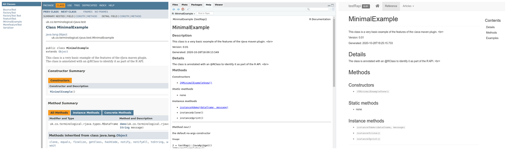

## Datatype transformation

### R to Java - runtime library

## Debugging Java code

- Datasets for testing Java code / serialisation of inputs
- Debugging flag

# Benefits

- Low friction
- Minimal dependencies introduced.
- Java Library dependency packaging
- Accurate bidirectional transfer of data between R and Java
- Type safety
- Code completion and type hinting in R
- Fluent use of R data in java
- R Documentation
- Separation of concerns
- Maintenance

# Limitations

- Fat Jar bloat
- Recompilation and iterative development
- Naming collisions
- Concurrent use of Multiple rJava libraries
- Java class caching

# Future development

- Tighter integration of multithreading and promises.
- Matrix support
- Named rows in dataframes
- R test case generation
- Java object bindings
- Purrr style lists in data frames

# References

Chang, Winston. 2019. *R6: Encapsulated Classes with Reference Semantics* (version 2.4.1). https://CRAN.R-project.org/package=R6.

Gilbert, Floid R., and David B. Dahl. 2020a. *Jdx: ’Java’ Data Exchange for ’R’ and ’rJava’* (version 0.1.4). https://CRAN.R-project.org/package=jdx.

———. 2020b. *Jsr223: A ’Java’ Platform Integration for ’R’ with Programming Languages ’Groovy’, ’JavaScript’, ’JRuby’ (’Ruby’), ’Jython’ (’Python’), and ’Kotlin’* (version 0.3.4). https://CRAN.R-project.org/package=jsr223.

*Terminological/R6-Generator-Maven-Plugin*. (2020) 2020. terminological. https://github.com/terminological/r6-generator-maven-plugin.

Urbanek, Simon. 2020. *rJava: Low-Level R to Java Interface* (version 0.9-13). https://CRAN.R-project.org/package=rJava.